# Synthetic NF1 MRI Images - Exploratory Data Analysis

## 1. Project datasheet

| Category | Value |
| --- | --- |
| Project | Synthetic NF1 MRI Images `(syn26010238)` |
| Team | DCD `(3430042)` |
| Competition | Hack4Rare 2021 |
| Description | script of exploratory data analysis |
| Additional requirements | you need to have the dataset `syn20608511` |

## 2. Imports

Project level imports include check of folders. It produces an output.

```python
# Import from standard library
from collections import Counter
from os import listdir
from os.path import isdir, isfile, join
from random import choice

# 3rd party imports
import matplotlib.pyplot as plt
import nibabel as nib
import numpy as np
import pandas as pd
import pydicom
import seaborn as sns

# project level imports
from config import Folder
import constants
import enum_handler

# Jupyter Notebook magic.
%matplotlib inline
```

```
[+] Folder ROOT is OK at `./data` path.
[+] Folder CASES is OK at `./data/Imaging Data` path.
[+] Folder REPORT is OK at `./data/report` path.
[+] Folder SEGMENTATIONS is OK at `./data/report/segmentation_50cases` path.
```

## 3. Global variables and data elements

In this part global variables are initialized. They are grouped by content and usage.

### 3.1. Field identifiers

```python
column_names = enum_handler.get_values_from_enum(constants.Columns)
site_dict = enum_handler.get_contents_from_enum(constants.Sites, apply='counter')
type_dict = enum_handler.get_contents_from_enum(constants.Types, apply='counter')
```

### 3.2. List of patients

Patient IDs are extracted from the name of the data files.

```python
patient_ids = []
patients_files = [f for f in listdir(Folder.REPORT.value)
                  if isfile(join(Folder.REPORT.value, f)) and f.endswith('.xls')]
for patient_file in patients_files:
    patient_ids.append(patient_file.lstrip('wbmri_').rstrip('.xls'))
```

### 3.3. Patient related functions

Thi part contains functions that relates to patient data transformation.

```python
def concat_patients_data(patients_list : list) -> pd.DataFrame:
    """
    Concatenate pateint's dataframes
    ================================

    Parameters
    ----------
    patients_list : list
        List of patient IDs.

    Returns
    -------
    pd.DataFrame
        DataFrame of all patient data.
    """

    temp_df = pd.DataFrame(columns=column_names)
    for patient in patients_list:
        temp_df = temp_df.append(read_and_transform(patient))

    return temp_df


def read_and_transform(patient_id : str) -> pd.DataFrame:
    """
    Read patient data from XLS and transform to DataFrame
    =====================================================

    Parameters
    ----------
    patient_id : str
        ID of the patient to work with.

    Returns
    -------
    pd.DataFrame
        DataFrame of the patient data.
    """

    file_name = Folder.REPORT.value + '/wbmri_' + patient_id + '.xls'
    data = pd.read_excel(file_name, sheet_name='MRI Database', usecols='B:E')
    start = data.index[data.iloc[: , 0] == 'Site'].tolist()
    if len(start) == 1:
        start = start[0]
    else:
        start = None
    stop = data.index[data.isin(['Total (CC):']).any(axis=1)].tolist()
    if len(stop) == 1:
        stop = stop[0]
    else:
        stop = None
    if start is not None and stop is not None:
        data = pd.read_excel(file_name, sheet_name='MRI Database',
                             usecols='B:E',
                             skiprows=lambda x: x not in range(start + 1, stop))
        data.dropna(how='all', inplace=True)
        data.insert(0, 'Subject', patient_id)
    else:
        data = None
    return data
```

### 3.4. Remove datapoints

There are some tumors in the dataset which appear in more bodyparts at the same time. To have clear vision about the tumors at this stage removing those datapoints (in fact tumors) is a must.

```python
patient_data = concat_patients_data(patient_ids)
print(patient_data[patient_data['Site'] == '1,2,3,4,6,7'])
print(patient_data[patient_data['Site'] == '0,1'])
patient_data = patient_data[patient_data.Site != '1,2,3,4,6,7']
patient_data = patient_data[patient_data.Site != '0,1']
patient_data.reindex()
patient_data['Subject'] = patient_data['Subject'].astype('int32', copy=False)
patient_data['Type'] = patient_data['Type'].astype('int32', copy=False)
patient_data['Site'] = patient_data['Site'].astype('int32', copy=False)
```

```
  Subject         Site  Type   Volume Comment
0     107  1,2,3,4,6,7   1.0  9089.45    1-PN
  Subject Site  Type   Volume Comment
2     109  0,1   1.0  301.172    3-PN
```

### 3.5. Volume categories

To be able to build an overview about the data important measurements must be categorized. Volume is one of the most important measures in this dataset.

```python
def make_volume_categories(row : pd.Series) -> int:

    result = row['Volume'] // constants.Ranges.VOLUME.value
    if result > constants.Ranges.MAX_VOLUME.value:
        result = constants.Ranges.MAX_VOLUME.value
    return int(result)


patient_data['Volume_cat'] = patient_data.apply(make_volume_categories, axis=1)
```

## 4. Data overview

This part contains basic overview information about the whole dataset.

### 4.1. Database head

First 5 rows of the databes.

```python
patient_data.head(5)
```

|  | Subject | Site | Type | Volume | Comment | Volume_cat |
| --- | --- | --- | --- | --- | --- | --- |
| 0 | 10 | 3 | 0 | 15.1123 | NaN | 7 |
| 1 | 10 | 1 | 0 | 24.0234 | NaN | 12 |
| 2 | 10 | 1 | 0 | 31.6406 | NaN | 15 |
| 3 | 10 | 8 | 0 | 17.4561 | NaN | 8 |
| 4 | 10 | 1 | 0 | 132.6900 | > 5CM | 50 |

### 4.2. Database tail

Last 5 rows of the database.

```python
patient_data.tail(5)
```

|  | Subject | Site | Type | Volume | Comment | Volume_cat |
| --- | --- | --- | --- | --- | --- | --- |
| 1 | 279 | 3 | 0 | 4.85840 | 2-DF | 2 |
| 2 | 279 | 6 | 0 | 18.06640 | 3-DF | 9 |
| 3 | 279 | 7 | 0 | 6.22559 | 4-DF | 3 |
| 4 | 279 | 5 | 0 | 2.58789 | 5-DF | 1 |
| 5 | 279 | 2 | 0 | 1.90430 | 6-DF | 0 |

### 4.3. Databse overview

Number of rows, column names and column level overview of the content.

```python
patient_data.info()
```

```
<class 'pandas.core.frame.DataFrame'>
Int64Index: 904 entries, 0 to 5
Data columns (total 6 columns):
 #   Column      Non-Null Count  Dtype
---  ------      --------------  -----
 0   Subject     904 non-null    int32
 1   Site        904 non-null    int32
 2   Type        904 non-null    int32
 3   Volume      904 non-null    float64
 4   Comment     747 non-null    object
 5   Volume_cat  904 non-null    int64
dtypes: float64(1), int32(3), int64(1), object(1)
memory usage: 38.8+ KB
```

### 4.3. Database description

Column level overview of the databse.

```python
patient_data.describe()
```

|  | Subject | Site | Type | Volume | Volume_cat |
| --- | --- | --- | --- | --- | --- |
| count | 904.000000 | 904.000000 | 904.000000 | 904.000000 | 904.000000 |
| mean | 99.456858 | 3.845133 | 0.464602 | 41.298986 | 13.113938 |
| std | 63.077536 | 2.730071 | 0.499021 | 92.428470 | 16.340347 |
| min | 10.000000 | 0.000000 | 0.000000 | 0.366211 | 0.000000 |
| 25% | 47.000000 | 1.000000 | 0.000000 | 4.840090 | 2.000000 |
| 50% | 90.000000 | 3.000000 | 0.000000 | 10.839850 | 5.000000 |
| 75% | 127.000000 | 6.000000 | 1.000000 | 37.127725 | 18.000000 |
| max | 279.000000 | 11.000000 | 1.000000 | 1354.150000 | 50.000000 |

### 4.4. Unique values

Column level information about the unique datapoints.

```python
for column in patient_data.columns:
    print('{:7>} ({}):\n{}\n'.format(column, len(patient_data[column].unique()), patient_data[column].unique()))
```

```
Subject (49):
[ 10  19  23  27  32  35  36  45  47  48  52  53  61  63  65  69  72  76
  77  81  85  87  88  89  90  95  97  98  99 102 106 107 109 114 119 120
 123 127 136 138 144 158 196 222 224 225 227 268 279]

Site (12):
[ 3  1  8  2  7  0  6  5  4  9 10 11]

Type (2):
[0 1]

Volume (686):
[1.511230e+01 2.402340e+01 3.164060e+01 1.745610e+01 1.326900e+02
 9.448240e+00 4.697270e+01 3.637700e+01 2.246090e+00 4.821780e+01
 3.559570e+01 1.450200e+01 2.343750e+00 4.028320e+00 2.392580e+00
 2.880860e+00 4.338380e+01 1.298830e+01 2.563480e+00 4.516600e+00
 1.684570e+00 1.757810e+00 1.481930e+01 7.031250e+00 5.883790e+00
 7.788090e+00 4.321290e+00 6.225590e+00 3.247070e+00 1.068360e+02
 8.837890e+00 3.051760e+00 1.831050e+00 3.808590e+00 1.953130e+01
 1.203610e+01 7.519530e+00 3.613280e+00 2.400630e+02 4.614260e+00
 5.803220e+01 1.645510e+01 2.368160e+00 1.387700e+02 4.907230e+00
 2.465820e+00 2.929690e+00 8.642580e+00 2.270510e+00 1.008300e+01
 7.250980e+00 4.726560e+01 6.884770e+00 6.420900e+00 1.470210e+02
 3.662110e-01 4.858400e+00 5.312500e+01 1.257320e+01 7.011720e+01
 2.612300e+00 1.967770e+01 2.095950e+02 2.146000e+01 3.320310e+01
 1.311040e+01 2.929690e+01 2.905270e+00 2.019040e+01 1.723630e+01
 5.251460e+01 1.367190e+00 1.223140e+01 1.357420e+01 4.465090e+02
 3.930660e+00 1.882320e+02 1.879880e+01 3.977050e+01 6.037600e+01
 3.125000e+00 2.697750e+01 2.124020e+00 6.835940e+00 3.481450e+01
 1.650390e+01 2.250980e+01 4.074710e+01 9.956050e+01 1.066890e+01
 6.250000e+00 6.713870e+00 2.182620e+01 1.361570e+02 1.573730e+02
 2.229000e+01 5.249020e+00 1.135250e+01 4.052730e+00 2.721680e+02
 1.477050e+01 1.422360e+02 2.081540e+02 2.169920e+02 2.183110e+02
 9.912110e+00 5.905760e+01 3.615720e+01 4.136230e+02 1.442380e+02
 1.166750e+02 8.276370e+00 4.785160e+00 4.736330e+00 2.253420e+01
 4.086910e+01 6.247560e+01 4.453130e+01 7.568360e+01 4.541020e+00
 2.027100e+02 2.487790e+01 8.039550e+01 9.660640e+01 5.175780e+00
 1.237790e+01 1.613770e+01 6.054690e+00 7.763670e+00 2.856450e+00
 2.022460e+02 2.219730e+02 5.297850e+00 4.677730e+01 2.187500e+01
 1.130370e+01 1.862790e+01 2.177730e+01 1.263180e+02 2.551270e+01
```

[output cut: 138 more lines]

```
 '15-DF' '16-DF' '17-DF' '12-PF' '13-PF' '15-PF' '16-PF' '17-PF' '18-PF'
 '19-PF' '20-PF' '21-PF' '22-PF' '23-PF' '24-PF' '25-PF' '26-PF' '27-PF'
 '28-PF' '29-PF' '30-PF' '31-PF' '32-PF' '33-PF' '34-PF' '35-PF' '36-PF'
 '37-DF' '38-DF' '39-DF' '40-PF' '41-PF' '42-DF' '1-DF ' '2-DF ' '3-PF '
 '4-PF ' '5-PF ' '6-PF ' '7-DF ' '8-DF ' '9-PF ' '3-DF ' '4-DF ' '5-DF '
 '6-DF ' '9-DF ' '18-DF' '19-DF' '20-DF' '23-DF' '24-DF' '25-DF' '26-DF'
 '29-DF' '30-DF' '31-DF' '33-DF' '34-DF' '35-DF' '37-PF' '40-Df' '41-DF'
 '43-DF' '44-DF' '45-DF' '46-DF' '47-DF' '48-DF' '49-DF' '50-Df' '51-DF'
 '52-DF' '53-DF' '54-DF' '55-DF' '56-DF' '57-DF' '58-DF' '59-DF' '60-DF'
 '61-DF' '62-DF' '63-PF' '64-DF' '65-DF' '66-DF']

Volume_cat (50):
[ 7 12 15  8 50  4 23 18  1 24 17  2 21  6  0  3  9 29  5 26 35 10 16 14
 19 30 13 11 20 49 31 22 37 40 48 28 36 25 32 41 33 27 46 43 45 34 42 47
 39 44]
```

## 5. Graphs

### 5.1. Locations of tumors

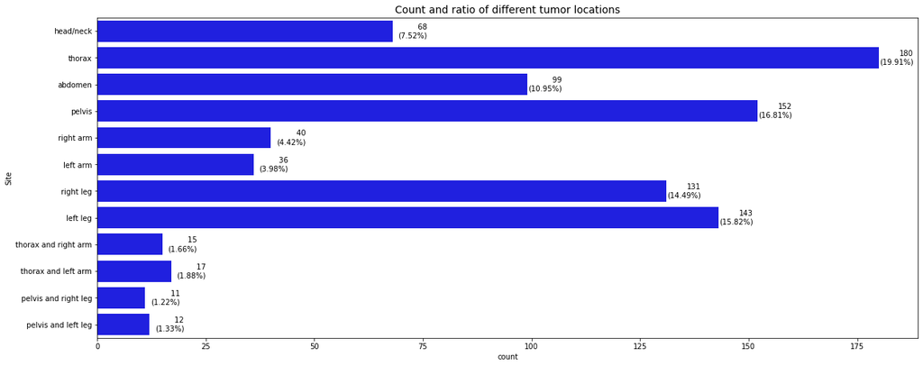

```python
site_counts = patient_data['Site'].value_counts()
site_order = site_counts.index
tick_name = [site_dict[tick] for tick in site_order]

plt.figure(figsize=(20,8))
sns.countplot(y='Site',
              data=patient_data,
              color='blue').set_title('Count and ratio of different tumor locations').set_fontsize(14)
len_data = len(patient_data)
plt.yticks(site_order, tick_name)

for i in range(site_counts.shape[0]):
    count = site_counts[i]
    text = '{:3d}\n({:4.2f}%)'.format(count, count/len_data*100)
    plt.text(count+8, i, text,  va='center', ha='right')

plt.show()
```

Tumors in thorax and pelvis are the most common, right and left legs are the next most common locations. Bi.located tumors are the most less common types.

### 5.2. Tumor types and sites (location)

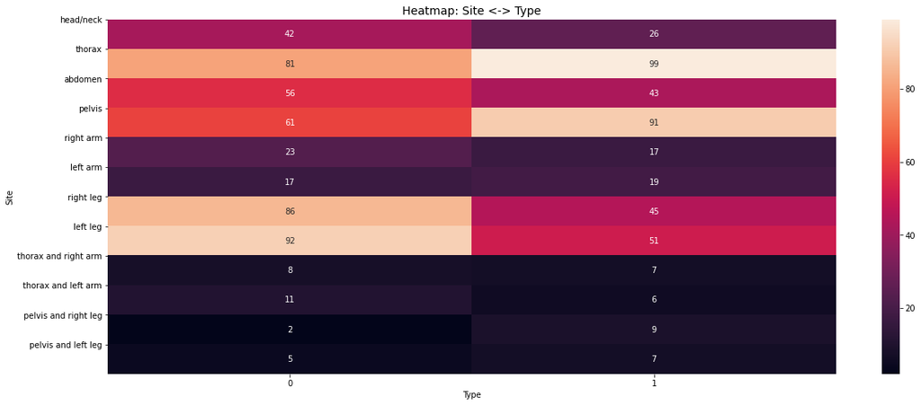

```python
site_type_counts = patient_data.groupby(['Site', 'Type']).size()
site_type_counts = site_type_counts.reset_index(name='Count')
site_type_counts = site_type_counts.pivot(index='Site', columns='Type', values='Count')

y_ticks = [site_dict[key] for key, value in site_dict.items()]
order = [i for i, _ in enumerate(y_ticks)]

plt.figure(figsize=(20,8))
sns.heatmap(site_type_counts, annot=True, fmt='d').set_title('Heatmap: Site <-> Type').set_fontsize(14)
plt.yticks(order, y_ticks, rotation='horizontal')
plt.show()
```

Hint:

- Type `0` is for `discrete` tumors, type `1` is for `plexiform` tumors.

### 5.3. Volume categories and type

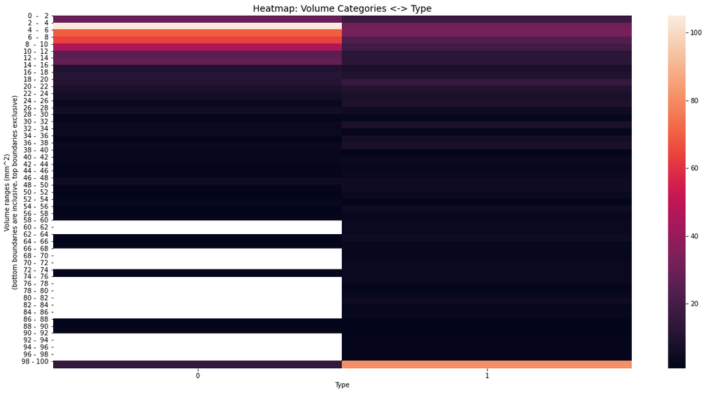

```python
volume_type_counts = patient_data.groupby(['Volume_cat', 'Type']).size()
volume_type_counts = volume_type_counts.reset_index(name='Count')
volume_type_counts = volume_type_counts.pivot(index='Volume_cat', columns='Type', values='Count')

y_ticks = ['{:<2d} - {:3d}'.format(x * constants.Ranges.VOLUME.value,
                                   x * constants.Ranges.VOLUME.value + constants.Ranges.VOLUME.value)
           for x in range(len(volume_type_counts))]
order = [i for i, _ in enumerate(y_ticks)]

plt.figure(figsize=(20,10))
sns.heatmap(volume_type_counts).set_title('Heatmap: Volume Categories <-> Type').set_fontsize(14)
plt.yticks(order, y_ticks, rotation='horizontal')
plt.ylabel('Volume ranges (mm^2)\n(bottom boundaries are inclusive, top boundaries exclusive)')
plt.show()
```

Hint:

- area without color means there is no datapoint at all.
- however last category is shown as **98-100** it means **above 98**.

Based on this dataset only it is not available to train for every volume categories and type.

### 5.3. Volume categories and site (location)

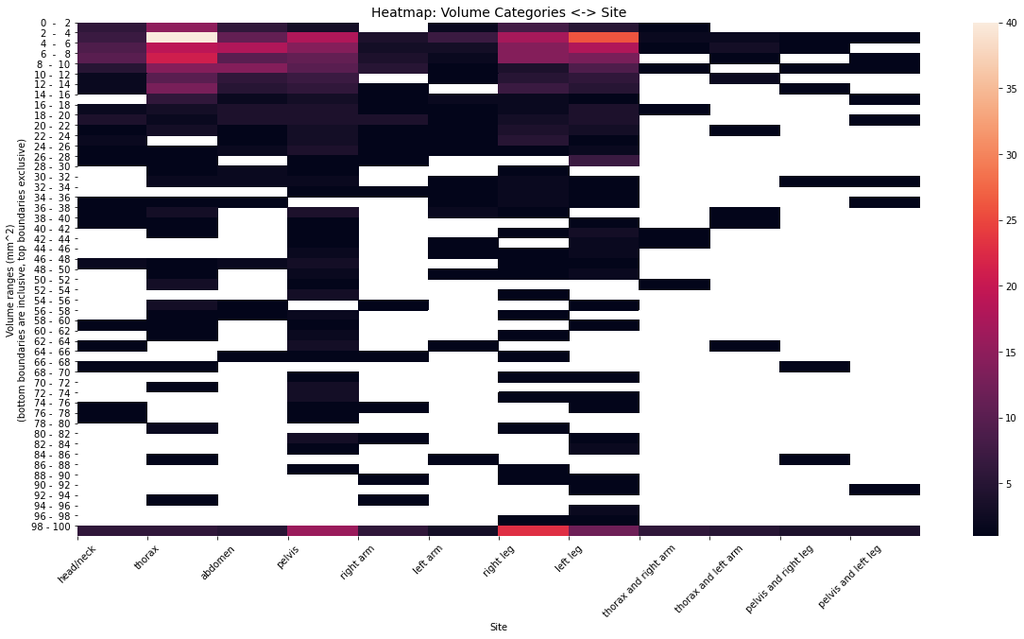

```python
volume_site_counts = patient_data.groupby(['Volume_cat', 'Site']).size()
volume_site_counts = volume_site_counts.reset_index(name='Count')
volume_site_counts = volume_site_counts.pivot(index='Volume_cat', columns='Site', values='Count')

x_ticks = [site_dict[key] for key, value in site_dict.items()]
x_order = [i for i, _ in enumerate(x_ticks)]
y_ticks = ['{:<2d} - {:3d}'.format(x * constants.Ranges.VOLUME.value,
                                   x * constants.Ranges.VOLUME.value + constants.Ranges.VOLUME.value)
           for x in range(len(volume_type_counts))]
y_order = [i for i, _ in enumerate(y_ticks)]

plt.figure(figsize=(20,10))
sns.heatmap(volume_site_counts).set_title('Heatmap: Volume Categories <-> Site').set_fontsize(14)
plt.xticks(x_order, x_ticks, rotation=45)
plt.yticks(y_order, y_ticks, rotation='horizontal')
plt.ylabel('Volume ranges (mm^2)\n(bottom boundaries are inclusive, top boundaries exclusive)')
plt.show()
```

Hint:

- area without color means there is no datapoint at all.
- however last category is shown as **98-100** it means **above 98**.

The dataset doesn't contain samples for the majority of the volume category - site combinations.

## 6. Without bilocation

From the perspective of an AI development it's hard to handle tumors that present in more parts of the body at the same time. Therefore figuring out a method to handle this situation is a must.

### 6.1. Data merging

Merging of the site data is a possible way to simplify the problem without losing value of data.

#### 6.1.1. Code

```python
def merge_patients_data(data_slice : pd.DataFrame, source : int, targets : tuple,
                        remove : bool = True, verbose : bool = True) -> pd.DataFrame:
    """
    Merge sites
    ===========

    Parameters
    ----------
    data_slice : pd.DataFrame
        Data frame to use data for site merging.
    source : int
        Values as merge base.
    targets : tuple
        Values as merge targets.
    remove : bool, optionalTrue if omitted)
        Whether to remove merged elements or not.
    verbose : bool, optional (True if imotted)
        Whether to print status messages or not.

    Returns
    -------
    pd.DataFrame
        The dataframe with the merged sites.
    """

    if verbose:
        print('\nLength of original data: {}'.format(len(data_slice)))
    result = data_slice[:]
    temp_df = data_slice[patient_data_merged['Site'] == source]
    with pd.option_context('mode.chained_assignment', None):
        for target in targets:
            temp_df['Site'] = target
            result = result.append(temp_df)
            if verbose:
                print('{} records are added as {}'.format(len(temp_df), target))

    if remove:
        if verbose:
            print('{} records are deleted as {}'.format(len(result[result['Site'] == source]), source))
        result = result[result['Site'] != source]
        if verbose:
            print('Length of the merged data: {}'.format(len(result)))

    return result
```

##### 6.1.2. The process

The cell outputs the result of the merging process.

```python
patient_data_merged = patient_data[:]
patient_data_merged = merge_patients_data(patient_data_merged, 8, (1, 4))
patient_data_merged = merge_patients_data(patient_data_merged, 9, (1, 5))
patient_data_merged = merge_patients_data(patient_data_merged, 10, (3, 6))
patient_data_merged = merge_patients_data(patient_data_merged, 11, (3, 7))
```

```
Length of original data: 904
15 records are added as 1
15 records are added as 4
15 records are deleted as 8
Length of the merged data: 919

Length of original data: 919
17 records are added as 1
17 records are added as 5
17 records are deleted as 9
Length of the merged data: 936

Length of original data: 936
11 records are added as 3
11 records are added as 6
11 records are deleted as 10
Length of the merged data: 947

Length of original data: 947
12 records are added as 3
12 records are added as 7
12 records are deleted as 11
Length of the merged data: 959
```

#### 6.1.3. Column level stats

```python
patient_data_merged.describe()
```

|  | Subject | Site | Type | Volume | Volume_cat |
| --- | --- | --- | --- | --- | --- |
| count | 959.000000 | 959.000000 | 959.000000 | 959.000000 | 959.000000 |
| mean | 99.241919 | 3.500521 | 0.468196 | 45.036035 | 13.755996 |
| std | 62.664646 | 2.361785 | 0.499248 | 100.426629 | 16.849478 |
| min | 10.000000 | 0.000000 | 0.000000 | 0.366211 | 0.000000 |
| 25% | 47.000000 | 1.000000 | 0.000000 | 4.907230 | 2.000000 |
| 50% | 90.000000 | 3.000000 | 0.000000 | 11.254900 | 5.000000 |
| 75% | 127.000000 | 6.000000 | 1.000000 | 40.954550 | 20.000000 |
| max | 279.000000 | 7.000000 | 1.000000 | 1354.150000 | 50.000000 |

### 6.2. Graphs

#### 6.2.1. Location of tumors

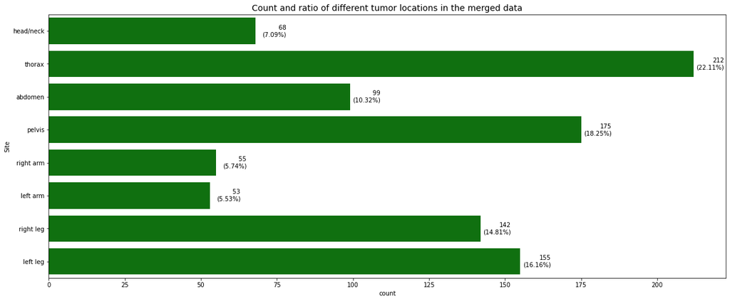

```python
site_counts = patient_data_merged['Site'].value_counts()
site_order = site_counts.index
tick_name = [site_dict[tick] for tick in site_order]

plt.figure(figsize=(20,8))
sns.countplot(y='Site',
              data=patient_data_merged,
              color='green').set_title('Count and ratio of different tumor locations in the merged data').set_fontsize(14)
len_data = len(patient_data_merged)
plt.yticks(site_order, tick_name)

for i in range(site_counts.shape[0]):
    count = site_counts[i]
    text = '{:3d}\n({:4.2f}%)'.format(count, count/len_data*100)
    plt.text(count+10, i, text,  va='center', ha='right')

plt.show()
```

#### 6.2.2. Tumor types and sites (location)

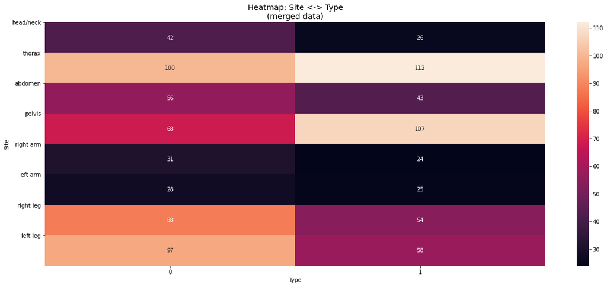

```python
site_type_counts = patient_data_merged.groupby(['Site', 'Type']).size()
site_type_counts = site_type_counts.reset_index(name='Count')
site_type_counts = site_type_counts.pivot(index='Site', columns='Type', values='Count')

y_ticks = [site_dict[key] for key, value in site_dict.items()]
y_order = [i for i, _ in enumerate(y_ticks)]

y_ticks, y_order = y_ticks[0:8], y_order[0:8]

plt.figure(figsize=(20,8))
sns.heatmap(site_type_counts, annot=True, fmt='d').set_title('Heatmap: Site <-> Type\n(merged data)').set_fontsize(14)
plt.yticks(y_order, y_ticks, rotation='horizontal')
plt.show()
```

#### 6.2.3. Volume categories and type

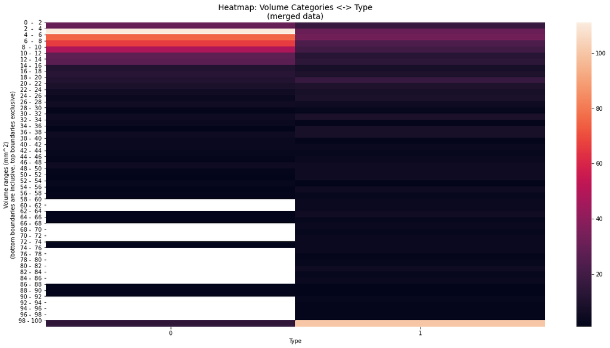

```python
volume_type_counts = patient_data_merged.groupby(['Volume_cat', 'Type']).size()
volume_type_counts = volume_type_counts.reset_index(name='Count')
volume_type_counts = volume_type_counts.pivot(index='Volume_cat', columns='Type', values='Count')

y_ticks = ['{:<2d} - {:3d}'.format(x * constants.Ranges.VOLUME.value,
                                   x * constants.Ranges.VOLUME.value + constants.Ranges.VOLUME.value)
           for x in range(len(volume_type_counts))]
order = [i for i, _ in enumerate(y_ticks)]

plt.figure(figsize=(20,10))
sns.heatmap(volume_type_counts).set_title('Heatmap: Volume Categories <-> Type\n(merged data)').set_fontsize(14)
plt.yticks(order, y_ticks, rotation='horizontal')
plt.ylabel('Volume ranges (mm^2)\n(bottom boundaries are inclusive, top boundaries exclusive)')
plt.show()
```

#### 6.2.4. Volume categories and site (location)

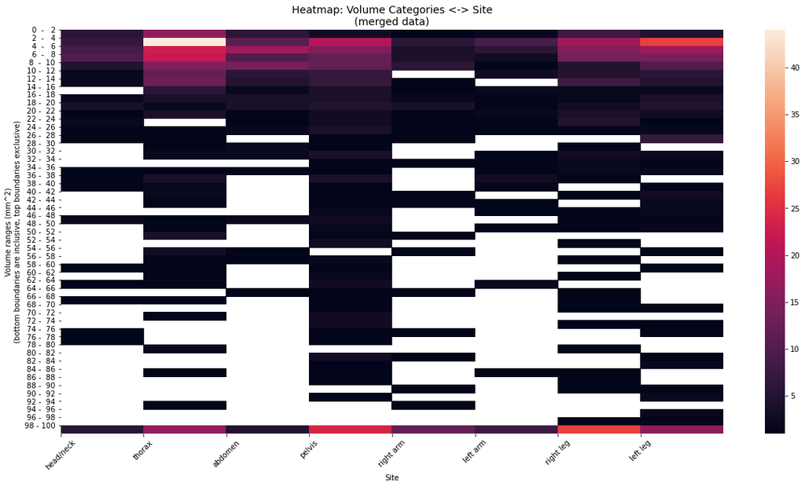

```python
volume_site_counts = patient_data_merged.groupby(['Volume_cat', 'Site']).size()
volume_site_counts = volume_site_counts.reset_index(name='Count')
volume_site_counts = volume_site_counts.pivot(index='Volume_cat', columns='Site', values='Count')

x_ticks = [site_dict[key] for key, value in site_dict.items()]
x_order = [i for i, _ in enumerate(x_ticks)]
y_ticks = ['{:<2d} - {:3d}'.format(x * constants.Ranges.VOLUME.value,
                                   x * constants.Ranges.VOLUME.value + constants.Ranges.VOLUME.value)
           for x in range(len(volume_type_counts))]
y_order = [i for i, _ in enumerate(y_ticks)]

x_ticks, x_order = x_ticks[0:8], x_order[0:8]

plt.figure(figsize=(20,10))
sns.heatmap(volume_site_counts).set_title('Heatmap: Volume Categories <-> Site\n(merged data)').set_fontsize(14)
plt.xticks(x_order, x_ticks, rotation=45)
plt.yticks(y_order, y_ticks, rotation='horizontal')
plt.ylabel('Volume ranges (mm^2)\n(bottom boundaries are inclusive, top boundaries exclusive)')
plt.show()
```

## 7. Imaging data - DICOM

GAN architecture needs original images to learn.

### 7.1. Collect images

Images of the dataset are in different folders. A custom collection method is needed.

```python
def get_dicomlist(patient_id : str) -> list:
    """
    Get list of existing DICOM images of a patient
    ==============================================

    Parameters
    ----------
    patient_id : str
        ID of the patient to collect files.

    Returns
    -------
    list
        List of file paths to the patient's DICOM files.
    """

    result = []
    patient_root = join(Folder.CASES.value, 'WBMRI{}/DICOM/'.format(patient_id))
    if isdir(patient_root):
        directories = [join(patient_root, d) for d in listdir(patient_root)
                         if isdir(join(patient_root, d))]
        for directory in directories:
            for file_name in listdir(directory):
                full_path = join(directory, file_name)
                if isfile(full_path) and full_path.endswith('.dcm'):
                    result.append(full_path)
    return result
```

```python
patientlist = [d.replace('WBMRI', '') for d in listdir(Folder.CASES.value)
                                   if isdir(join(Folder.CASES.value, d))]
```

This cell below tests whether all patient has the appropriate folders to have imaging data or not.

Note:

- There are patients who doesn't have `.dcm` files in their folders bot they have folder. This is the reason why this test doesn't show error if you have the whole dataset.

```python
if len(patient_ids) == len(set(patient_ids + patientlist)):
    print('[+] Patients list is OK.')
else:
    print('[!] Number of patients in reports does not equals with the number of patients in the cases.')
```

```
[+] Patients list is OK.
```

```python
dicom_paths = []
dicom_path_patients = {}

for patient_id in patient_ids:
    dicom_list = get_dicomlist(patient_id)
    for dicom_path in dicom_list:
        dicom_paths.append(dicom_path)
        if patient_id in dicom_path_patients.keys():
            dicom_path_patients[patient_id].append(dicom_path)
        else:
            dicom_path_patients[patient_id] = []
```

```python
dicom_files = []
for i in range(7):
    dicom_files.append(pydicom.dcmread(choice(dicom_paths)))
```

### 7.2. Sample images

Let's see how patient's MRI images look like.

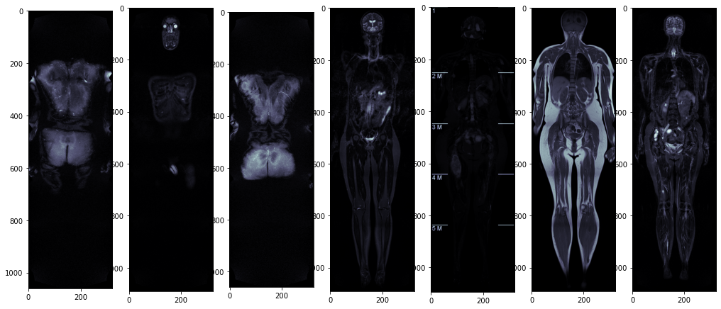

```python
f = plt.figure()
f.set_figheight(10)
f.set_figwidth(25)

for i, dicom in enumerate(dicom_files):
    p = f.add_subplot(1, 10, i+1)
    img_data = dicom.pixel_array
    plt.imshow(img_data, cmap='bone')

plt.show()
```

### 7.3. Shapes

Because of the requirements of the DL models insights about shapes of images are also needed.

```python
img_shapes_x = []
img_shapes_y = []

for dicom in dicom_paths:
    dicom_file = pydicom.dcmread(dicom)
    shape = dicom_file.pixel_array.shape
    img_shapes_x.append(shape[1])
    img_shapes_y.append(shape[0])
```

```python
print('X min: {:>4} - X max: {:>4}'.format(min(img_shapes_x), max(img_shapes_x)))
print('Y min: {:>4} - Y max: {:>4}'.format(min(img_shapes_y), max(img_shapes_y)))
```

```
X min:  320 - X max:  324
Y min:  889 - Y max: 1105
```

### 7.4. Additional info

Let's see if `DICOM` files contain any useful information to pair them with `.nii` files or not.

```python
print(dicom_file)
```

```
Dataset.file_meta -------------------------------
(0002, 0000) File Meta Information Group Length  UL: 222
(0002, 0001) File Meta Information Version       OB: b'\x00\x01'
(0002, 0002) Media Storage SOP Class UID         UI: MR Image Storage
(0002, 0003) Media Storage SOP Instance UID      UI: 1.3.6.1.4.1.5962.99.1.3785683421.1058084306.1567153811933.7879.0
(0002, 0010) Transfer Syntax UID                 UI: Explicit VR Little Endian
(0002, 0012) Implementation Class UID            UI: 1.3.6.1.4.1.5962.99.2
(0002, 0013) Implementation Version Name         SH: 'PIXELMEDJAVA001'
(0002, 0016) Source Application Entity Title     AE: 'DAOZI_11112'
-------------------------------------------------
(0008, 0008) Image Type                          CS: ['DERIVED', 'SECONDARY', 'M', 'DIS2D', 'COMP_AN', 'COMPOSED']
(0008, 0012) Instance Creation Date              DA: '20101027'
(0008, 0013) Instance Creation Time              TM: '164217.921000'
(0008, 0016) SOP Class UID                       UI: MR Image Storage
(0008, 0018) SOP Instance UID                    UI: 1.3.6.1.4.1.5962.99.1.3785683421.1058084306.1567153811933.7879.0
(0008, 0020) Study Date                          DA: '20101027'
(0008, 0021) Series Date                         DA: '20101027'
(0008, 0022) Acquisition Date                    DA: '20101027'
(0008, 0023) Content Date                        DA: '20101027'
(0008, 0030) Study Time                          TM: '155828.906000'
(0008, 0031) Series Time                         TM: '164304.687000'
(0008, 0032) Acquisition Time                    TM: '161455.262500'
(0008, 0033) Content Time                        TM: '164217.921000'
(0008, 0050) Accession Number                    SH: ''
(0008, 0060) Modality                            CS: 'MR'
(0008, 0070) Manufacturer                        LO: 'SIEMENS'
(0008, 0090) Referring Physician's Name          PN: ''
(0008, 1010) Station Name                        SH: 'MR1Y6'
(0008, 1090) Manufacturer's Model Name           LO: 'Avanto'
(0008, 1140)  Referenced Image Sequence   1 item(s) ----
   (0008, 1150) Referenced SOP Class UID            UI: MR Image Storage
   (0008, 1155) Referenced SOP Instance UID         UI: 1.3.6.1.4.1.5962.99.1.3785683421.1058084306.1567153811933.7636.0
   ---------
(0008, 2112)  Source Image Sequence   100 item(s) ----
   (0008, 1150) Referenced SOP Class UID            UI: MR Image Storage
   (0008, 1155) Referenced SOP Instance UID         UI: 1.3.6.1.4.1.5962.99.1.3785683421.1058084306.1567153811933.7759.0
   ---------
   (0008, 1150) Referenced SOP Class UID            UI: MR Image Storage
   (0008, 1155) Referenced SOP Instance UID         UI: 1.3.6.1.4.1.5962.99.1.3785683421.1058084306.1567153811933.7760.0
   ---------
```

[output cut: 371 more lines]

```
(0028, 0002) Samples per Pixel                   US: 1
(0028, 0004) Photometric Interpretation          CS: 'MONOCHROME2'
(0028, 0010) Rows                                US: 1061
(0028, 0011) Columns                             US: 323
(0028, 0030) Pixel Spacing                       DS: [1.5625, 1.5625]
(0028, 0100) Bits Allocated                      US: 16
(0028, 0101) Bits Stored                         US: 12
(0028, 0102) High Bit                            US: 11
(0028, 0103) Pixel Representation                US: 0
(0028, 1050) Window Center                       DS: "579.0"
(0028, 1051) Window Width                        DS: "708.0"
(0028, 1055) Window Center & Width Explanation   LO: 'WINDOW1'
(0040, 0244) Performed Procedure Step Start Date DA: '20101027'
(0040, 0245) Performed Procedure Step Start Time TM: '155829.000000'
(7fe0, 0010) Pixel Data                          OW: Array of 685406 elements
```

From the perspective of our project unfortunately no useful data exist in the headers.

## 8. Imaging data - Nibabel

To identify the locations and volumes of tumors on the images, data that relates to this information, is also needed. This belongs to the next steps of the development.

### 8.1. Collect images

```python
nib_files = [f for f in listdir(Folder.SEGMENTATIONS.value)
             if isfile(join(Folder.SEGMENTATIONS.value, f)) and f.endswith('.nii')]

nib_data = {}
nib_patients = []

for file in nib_files:
    patient = file[13:16]
    nib_patients.append(patient)
    nib_data[patient] = nib.load(Folder.SEGMENTATIONS.value + '/{}'.format(file))
```

### 8.2. Sample and visualize data

```
Patient: 010
Slice:  0 - [(0, 349692)]
Slice:  1 - [(0, 349692)]
Slice:  2 - [(0, 349692)]
Slice:  3 - [(0, 349682), (9, 10)]
Slice:  4 - [(0, 349592), (9, 55), (10, 45)]
Slice:  5 - [(0, 349242), (9, 27), (10, 423)]
Slice:  6 - [(0, 349070), (2, 32), (3, 22), (9, 27), (10, 568)]
Slice:  7 - [(0, 348261), (2, 419), (3, 414), (6, 31), (9, 27), (10, 567)]
Slice:  8 - [(0, 348282), (2, 347), (3, 496), (5, 158), (6, 85), (9, 27), (10, 324)]
Slice:  9 - [(0, 347975), (2, 186), (3, 346), (4, 183), (5, 835), (6, 119), (9, 27), (10, 48)]
Slice: 10 - [(0, 347779), (2, 186), (3, 18), (4, 265), (5, 1102), (6, 135), (7, 393), (9, 27), (10, 48)]
Slice: 11 - [(0, 347581), (2, 186), (3, 18), (4, 241), (5, 1200), (6, 17), (7, 545), (8, 108), (9, 27), (10, 48)]
Slice: 12 - [(0, 347852), (2, 186), (3, 18), (4, 26), (5, 1085), (6, 17), (7, 501), (8, 228), (9, 27), (10, 48)]
Slice: 13 - [(0, 348442), (2, 186), (3, 18), (4, 26), (5, 610), (6, 17), (7, 306), (8, 334), (9, 27), (10, 48)]
Slice: 14 - [(0, 348849), (2, 186), (3, 18), (4, 26), (5, 336), (6, 17), (7, 179), (8, 328), (9, 27), (10, 48)]
Slice: 15 - [(0, 349227), (1, 129), (2, 186), (3, 18), (4, 26), (5, 109), (6, 17), (7, 179), (8, 227), (9, 27), (10, 48)]
Slice: 16 - [(0, 349360), (1, 216), (2, 186), (3, 18), (4, 26), (5, 109), (6, 17), (7, 179), (8, 116), (9, 27), (10, 48)]
Slice: 17 - [(0, 349407), (1, 146), (2, 186), (3, 18), (4, 26), (5, 109), (6, 17), (7, 179), (8, 139), (9, 27), (10, 48)]
Slice: 18 - [(0, 349554), (1, 128), (2, 186), (3, 18), (4, 26), (5, 109), (6, 17), (7, 179), (8, 10), (9, 27), (10, 48)]
Slice: 19 - [(0, 349692), (1, 128), (2, 186), (3, 18), (4, 26), (5, 109), (6, 17), (7, 179), (8, 10), (9, 27), (10, 48)]
```

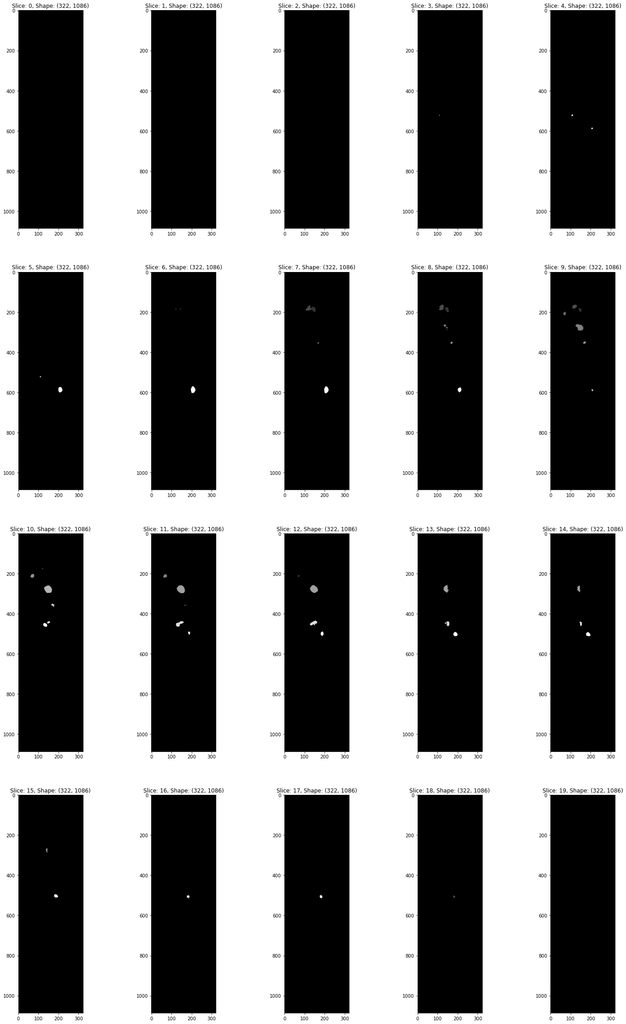

```python
nib_patient_count = len(nib_data)
paient_10_nib = []

for patient, nib_point in nib_data.items():

        pixel_counter = Counter()
        img = nib_point.get_fdata()
        paient_10_nib.append(img)

        slice_count = img.shape[2]
        print('Patient: {}'.format(patient))

        f = plt.figure()
        f.set_figheight(40)
        f.set_figwidth(25)

        p = []
        for j in range(slice_count):
            p.append(f.add_subplot(4, slice_count // 4 , j + 1))
            unique, counts = np.unique(img[:,:,j], return_counts=True)

            for u, c in zip(unique, counts):
                pixel_counter[int(u)] = int(c)

            pos = img[:,:,j] // 2
            p[-1].set_title('Slice: {}, Shape: {}'.format(j, img[:,:,j].shape))
            plt.imshow(img[:,:,j].T, cmap='gray')

            print('Slice: {:2d} - {}'.format(j, sorted(pixel_counter.items())))

        plt.show()

        if patient == '010':
            break
```

### 8.3. Additional informations

Let's see if it helps to pair images or not.

```python
nib_data['010'].header.structarr
```

```
array((348, b'', b'', 0, 0, b'r', 0, [   3,  322, 1086,   20,    1,    1,    1,    1], 0., 0., 0., 0, 4, 16, 0, [ 1.    ,  1.5625,  1.5625, 10.    ,  0.    ,  0.    ,  0.    ,  0.    ], 0., nan, nan, 0, 0, 2, 0., 0., 0., 0., 0, 0, b'', b'', 1, 0, 0., 0., 1., -0., -0., 0., [0., 0., 0., 0.], [0., 0., …
      dtype=[('sizeof_hdr', '<i4'), ('data_type', 'S10'), ('db_name', 'S18'), ('extents', '<i4'), ('session_error', '<i2'), ('regular', 'S1'), ('dim_info', 'u1'), ('dim', '<i2', (8,)), ('intent_p1', '<f4'), ('intent_p2', '<f4'), ('intent_p3', '<f4'), ('intent_code', '<i2'), ('datatype', '<i2'), ('bi…
```

```python
print(nib_data['010'].header)
```

```
<class 'nibabel.nifti1.Nifti1Header'> object, endian='<'
sizeof_hdr      : 348
data_type       : b''
db_name         : b''
extents         : 0
session_error   : 0
regular         : b'r'
dim_info        : 0
dim             : [   3  322 1086   20    1    1    1    1]
intent_p1       : 0.0
intent_p2       : 0.0
intent_p3       : 0.0
intent_code     : none
datatype        : int16
bitpix          : 16
slice_start     : 0
pixdim          : [ 1.      1.5625  1.5625 10.      0.      0.      0.      0.    ]
vox_offset      : 0.0
scl_slope       : nan
scl_inter       : nan
slice_end       : 0
slice_code      : unknown
xyzt_units      : 2
cal_max         : 0.0
cal_min         : 0.0
slice_duration  : 0.0
toffset         : 0.0
glmax           : 0
glmin           : 0
descrip         : b''
aux_file        : b''
qform_code      : scanner
sform_code      : unknown
quatern_b       : 0.0
quatern_c       : 0.0
quatern_d       : 1.0
qoffset_x       : -0.0
qoffset_y       : -0.0
qoffset_z       : 0.0
srow_x          : [0. 0. 0. 0.]
srow_y          : [0. 0. 0. 0.]
srow_z          : [0. 0. 0. 0.]
intent_name     : b''
magic           : b'n+1'
```

There are no data fileds that match fields of `DICOM` files directly.

### 8.4. Shapes

Shapes can be a source of match making process as well.

Note:

- It is risky when aside from patient's ID shape is the only matching point of images.

```python
nib_data['010'].ndim
```

```
3
```

```python
nib_data['010'].shape
```

```
(322, 1086, 20)
```

### 8.5. Data characteristics

```python
print(np.min(nib_data['010'].get_fdata()))
print(np.max(nib_data['010'].get_fdata()))
```

```
0.0
10.0
```

```python
nib_data['010'].affine
```

```
array([[-1.5625,  0.    ,  0.    , -0.    ],
       [ 0.    , -1.5625,  0.    , -0.    ],
       [ 0.    ,  0.    , 10.    ,  0.    ],
       [ 0.    ,  0.    ,  0.    ,  1.    ]])
```

### 8.6. Sample and visualize the data

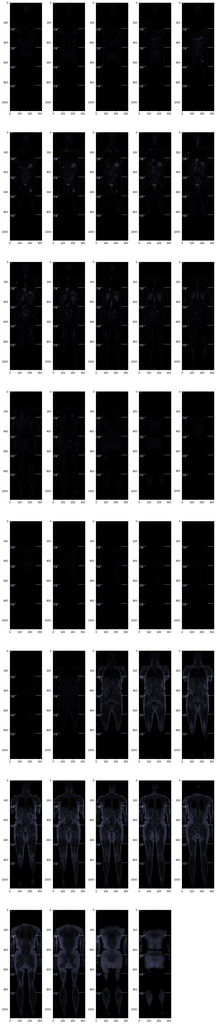

```python
patient_10 = []
patient_10_data = []

for dicom in dicom_path_patients['010']:
    patient_10.append(pydicom.dcmread(dicom))

f = plt.figure()
f.set_figheight(75)
f.set_figwidth(15)

for i, dicom in enumerate(patient_10):
    p = f.add_subplot(8, 5, i+1)
    img_data = dicom.pixel_array
    patient_10_data.append(img_data)
    plt.imshow(img_data, cmap='bone')

plt.show()
```